# Assignment B: Computer Vision (CS7GV1)

## Van Allen Bruns Jr - 19329560

# 3) Semantic segmentation (10 marks): Read paper Fully Convolutional Networks for Semantic Segmentation (https://people.eecs.berkeley.edu/~jonlong/long_shelhamer_fcn.pdf). From the class drive download script segmentation.py, containing example how to use pretrained models for semantic segmentation.

#### segmentation.py seen below.

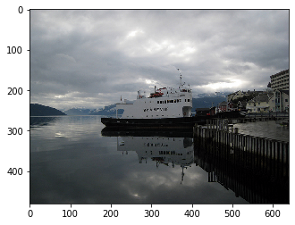

```
torch.Size([1, 21, 480, 640])
[0 4]
```

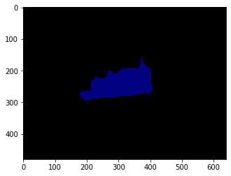

```python
# -*- coding: utf-8 -*-
"""
Based on code from
    https://colab.research.google.com/github/spmallick/learnopencv/blob/master/PyTorch-Segmentation-torchvision/intro-seg.ipynb
"""

from PIL import Image, ImageChops
import matplotlib.pyplot as plt
import torch
from torchvision import models
import numpy as np
import torchvision.transforms as T
import cv2

def decode_segmap(image, nc=21):

  label_colors = np.array([(0, 0, 0),  # 0=background
               # 1=aeroplane, 2=bicycle, 3=bird, 4=boat, 5=bottle
               (128, 0, 0), (0, 128, 0), (128, 128, 0), (0, 0, 128), (128, 0, 128),
               # 6=bus, 7=car, 8=cat, 9=chair, 10=cow
               (0, 128, 128), (128, 128, 128), (64, 0, 0), (192, 0, 0), (64, 128, 0),
               # 11=dining table, 12=dog, 13=horse, 14=motorbike, 15=person
               (192, 128, 0), (64, 0, 128), (192, 0, 128), (64, 128, 128), (192, 128, 128),
               # 16=potted plant, 17=sheep, 18=sofa, 19=train, 20=tv/monitor
               (0, 64, 0), (128, 64, 0), (0, 192, 0), (128, 192, 0), (0, 64, 128)])

  r = np.zeros_like(image).astype(np.uint8)
  g = np.zeros_like(image).astype(np.uint8)
  b = np.zeros_like(image).astype(np.uint8)

  for l in range(0, nc):
      idx = image == l
      r[idx] = label_colors[l, 0]
      g[idx] = label_colors[l, 1]
      b[idx] = label_colors[l, 2]

  rgb = np.stack([r, g, b], axis=2)
  return rgb


def apply_mask(im, im_pred):
    """
    Overlays the predicted class labels onto an image using the alpha channel.
    This function assumes that the background label is the black color.
    This function is provided as an inspiration for the masking function you should write.
    """
    r_channel, g_channel, b_channel = cv2.split(im_pred)
    alpha_channel = 127 * np.ones(b_channel.shape, dtype=b_channel.dtype)
    # Make background pixels fully transparent
    alpha_channel -= 127 * np.all(im_pred == np.array([0, 0, 0]), axis=2).astype(b_channel.dtype)
    im_pred = cv2.merge((r_channel, g_channel, b_channel, alpha_channel))
    mask = Image.fromarray(im_pred, mode='RGBA')
    masked_img = Image.fromarray(im)
    masked_img.paste(mask, box=None, mask=mask)
    return np.array(masked_img)

# define the model
fcn = models.segmentation.fcn_resnet101(pretrained=True).eval()

# load an image
img = Image.open('./boat.png')
plt.imshow(img);plt.show()

# transform the image
trf = T.Compose([T.ToTensor(),
                 T.Normalize(mean = [0.485, 0.456, 0.406],
                             std = [0.229, 0.224, 0.225])])
inp = trf(img).unsqueeze(0)

# pass the input through the net
out = fcn(inp)['out']
print (out.shape)

# calculate labels
om = torch.argmax(out.squeeze(), dim=0).detach().cpu().numpy()
print (np.unique(om))

# show segmentation output
rgb = decode_segmap(om)
plt.imshow(rgb); plt.show()
```

## a) Briefly explain:

### i) How FCN upsamples predictions to match the original image size.

Deconvolution with an output stride of f.

### ii) How had the authors improved the coarse predictions produced by the deepest layer.

A skip architecture that combines semantic information from the deepest layer with appearance information from a shallow, fine layer to produce accurate and detailed segmentations.

## b) Download YourEmail.png and take a class index assigned to you from classes.csv. Modify segmentation.py so that you predict segmentation mask of this class (by FCN model) on the image given to you and highlight prediction via red mask blended with the original image. Submit this image as YourEmail_predicted.png. See example output for the class 4 (boat) below.

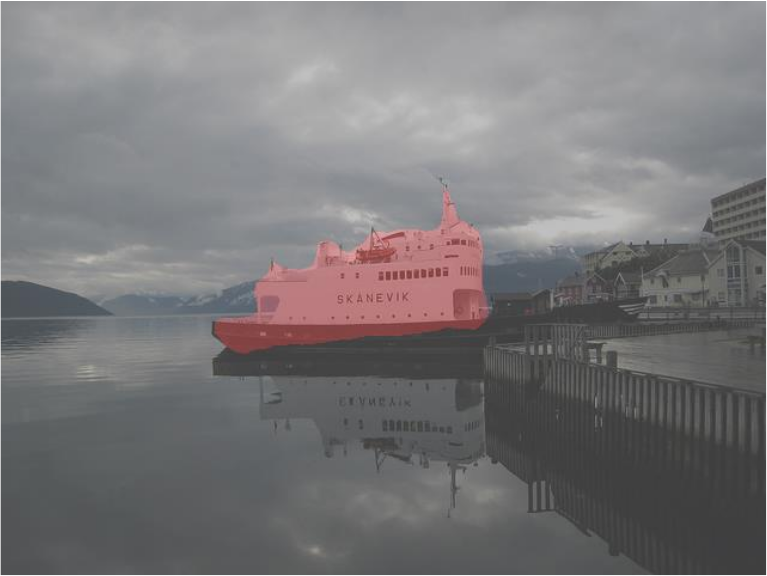

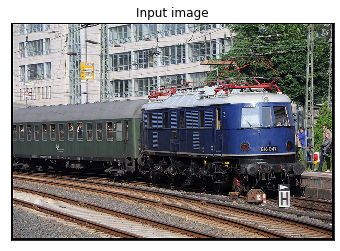

```
torch.Size([1, 21, 431, 640])
[ 0 15 19]
```

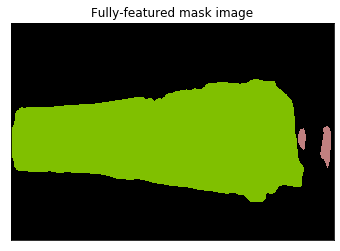

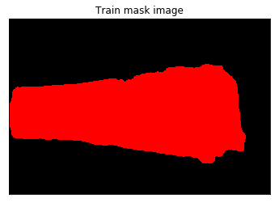

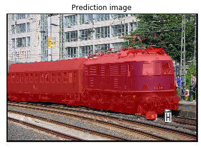

```python
def select_class(image, ci, color):
    label_colors = np.array([(0, 0, 0),  # 0=background
               # 1=aeroplane, 2=bicycle, 3=bird, 4=boat, 5=bottle
               (128, 0, 0), (0, 128, 0), (128, 128, 0), (0, 0, 128), (128, 0, 128),
               # 6=bus, 7=car, 8=cat, 9=chair, 10=cow
               (0, 128, 128), (128, 128, 128), (64, 0, 0), (192, 0, 0), (64, 128, 0),
               # 11=dining table, 12=dog, 13=horse, 14=motorbike, 15=person
               (192, 128, 0), (64, 0, 128), (192, 0, 128), (64, 128, 128), (192, 128, 128),
               # 16=potted plant, 17=sheep, 18=sofa, 19=train, 20=tv/monitor
               (0, 64, 0), (128, 64, 0), (0, 192, 0), (128, 192, 0), (0, 64, 128)])

    r, g, b = cv2.split(image)

    idx = r == label_colors[ci, 0]
    r[idx] = color[0]
    r[~idx] = 0

    idx = g == label_colors[ci, 1]
    g[idx] = color[1]
    g[~idx] = 0

    idx = b == label_colors[ci, 2]
    b[idx] = color[2]
    b[~idx] = 0

    rgb = np.stack([r, g, b], axis=2)

    return rgb

# Modified to take an image and copy it, then return the masked image.
def apply_mask(im, im_pred):
    """
    Overlays the predicted class labels onto an image using the alpha channel.
    This function assumes that the background label is the black color.
    This function is provided as an inspiration for the masking function you should write.
    """
    r_channel, g_channel, b_channel = cv2.split(im_pred)
    alpha_channel = 127 * np.ones(b_channel.shape, dtype=b_channel.dtype)
    # Make background pixels fully transparent
    alpha_channel -= 127 * np.all(im_pred == np.array([0, 0, 0]), axis=2).astype(b_channel.dtype)
    im_pred = cv2.merge((r_channel, g_channel, b_channel, alpha_channel))
    mask = Image.fromarray(im_pred, mode='RGBA')
    masked_img = im.copy()
    masked_img.paste(mask, box=None, mask=mask)
    return masked_img

# define the model
fcn = models.segmentation.fcn_resnet101(pretrained=True).eval()

# load an image
img = Image.open('./BRUNSJRV@TCD.IE.png')
plt.imshow(img);
plt.title('Input image')
plt.xticks([]), plt.yticks([])
plt.show()

# transform the image
trf = T.Compose([T.ToTensor(),
                 T.Normalize(mean = [0.485, 0.456, 0.406],
                             std = [0.229, 0.224, 0.225])])
inp = trf(img).unsqueeze(0)

# pass the input through the net
out = fcn(inp)['out']
print (out.shape)

# calculate labels
om = torch.argmax(out.squeeze(), dim=0).detach().cpu().numpy()
print (np.unique(om))

# show segmentation output
rgb = decode_segmap(om)
plt.imshow(rgb);
plt.title('Fully-featured mask image')
plt.xticks([]), plt.yticks([])
plt.show()

# select class
rgb = select_class(rgb, 19, [255, 0, 0])
plt.imshow(rgb);
plt.title('Train mask image')
plt.xticks([]), plt.yticks([])
plt.show()

# show masked image
masked_img = apply_mask(img, rgb)
plt.imshow(masked_img);
plt.title('Prediction image')
plt.xticks([]), plt.yticks([])
plt.show()

# save image
masked_img.save('./BRUNSJRV@TCD.IE_predicted.png')
```

## c) Decode the groundtruth image YourEmail_mask.png and calculate intersection over union (IOU) with the prediction for the class assigned to you. Report IOU in file YourEmail_iou.csv.

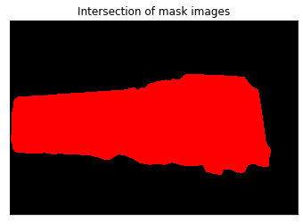

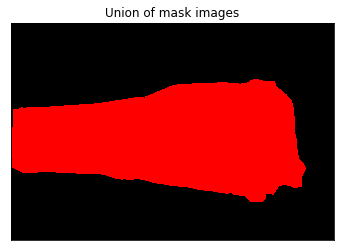

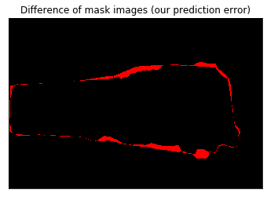

```
0.9361314234198137 - Intersection over union (prediction accuracy)
```

```python
import pandas as pd

def union(img1, img2):
    img1_ar = np.array(img1)
    img2_ar = np.array(img2)
    mask = img2_ar == 0
    img2_ar[mask] = img1_ar[mask]
    u_img = Image.fromarray(img2_ar)

    return u_img

def intersection(img1, img2):
    img1_ar = np.array(img1)
    img2_ar = np.array(img2)
    mask = np.logical_or(img1_ar == 0, img2_ar == 0)
    img2_ar[mask] = 0
    u_img = Image.fromarray(img2_ar)

    return u_img

# load mask
mask = Image.open('./BRUNSJRV@TCD.IE_mask.png')

# select class
mask = select_class(np.array(mask), 19, [255, 0, 0])

# intersection
i_img = intersection(mask, rgb)
plt.imshow(i_img);
plt.title('Intersection of mask images')
plt.xticks([]), plt.yticks([])
plt.show()

# union
u_img = union(mask, rgb)
plt.imshow(u_img);
plt.title('Union of mask images')
plt.xticks([]), plt.yticks([])
plt.show()

# difference (just for better visualization)
diff_img = ImageChops.difference(u_img, i_img)
plt.imshow(diff_img);
plt.title('Difference of mask images (our prediction error)')
plt.xticks([]), plt.yticks([])
plt.show()

# IOU
iou = np.sum(i_img) / np.sum(u_img)
print('{} - Intersection over union (prediction accuracy)'.format(iou))
pd.DataFrame({iou}).to_csv('./BRUNSJRV@TCD.IE_iou.csv', header=False, index=False)
```